# second week: Introduction to R and Rstudio

Mobile Data

Mina Moosavifar - 93106788

2018-02-19 18:14:43

[figure not shown]

# تمرین سری دوم: تلفن همراه شناسی!

> با استفاده از داده های گوشی های همراه به سوالات زیر پاسخ دهید. برای رسم نمودار از پکیج ggplot2 استفاده کنید.

۱. کدام شرکت بیشترین تعداد گوشی را تولید کرده است؟ نمودار ستونی ۲۰ شرکت برتر بر حسب تعداد گوشی تولید کرده را رسم کنید.

برای این منظور ابتدا بر اساس شرکت گروه بندی کرده و بعد تعداد را می شماریم. در نهایت ۲۰ شرکت اول در مرتب سازی نزولی جواب مورد نظر است.

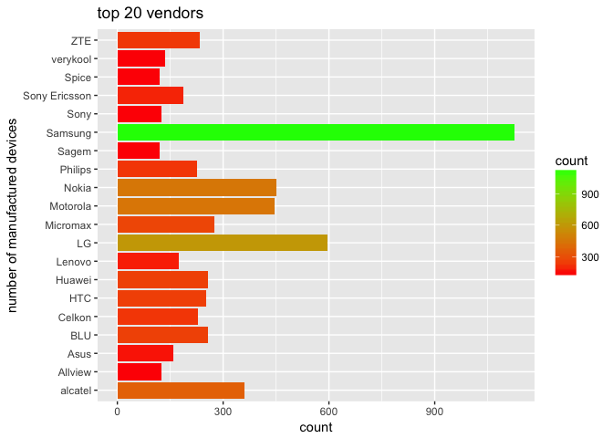

```r
library(readr)
library(dplyr)
library(ggplot2)
mobile = read_csv("data/mobile_data.csv")
most_devices = mobile %>% group_by(company) %>% summarise(count = n())

top_vendor = head(most_devices[order(most_devices$count, decreasing=TRUE), ], 20)

p = ggplot(data = top_vendor, aes(y = count, x = company, fill = count)) + geom_bar(stat="identity") + scale_fill_gradient(low="red", high="green") + coord_flip() + ggtitle("top 20 vendors") + xlab("number of manufactured devices")
p
```

```r
cat("most cellphone vendor: ", (most_devices$company[which.max(most_devices$count)]))
```

```
most cellphone vendor:  Samsung
```

۲. نمودار زمانی طول عرض ضخامت و کیفیت دوربین گوشی ها را بکشید و به نمودار هر یک مدل خطی اضافه کنید.

با نمودار scatter این داده ها را نمایش می دهیم و سپس به کمک geom_smooth در دو حالت خطی و منحنی مدل را رسم می کنیم.

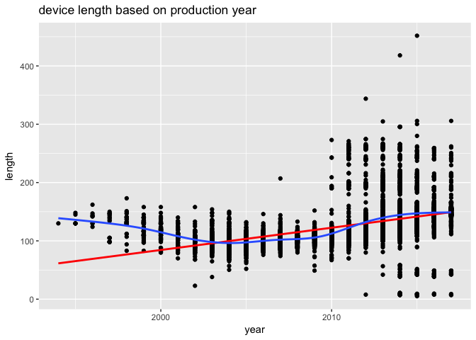

```r
# device_length = mobile %>% group_by(year) %>% summarise(average= mean(dim_length, na.rm = TRUE))

p_length = ggplot(data = mobile, mapping = aes(y = dim_length, x = year)) + geom_point(stat = "identity") + ggtitle('device length based on production year') + geom_smooth(method = "lm", se = FALSE, colour="red") + geom_smooth(se = FALSE) + ylab("length")
p_length
```

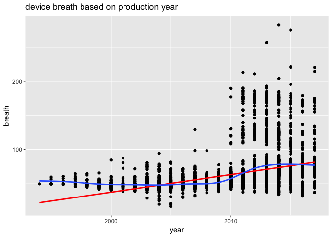

```r
# device_breath = mobile %>% group_by(year) %>% summarise(average= mean(dim_breadth, na.rm = TRUE))

p_breath = ggplot(data = mobile, mapping = aes(y = dim_breadth, x = year)) + geom_point(stat = "identity") + ggtitle('device breath based on production year') + geom_smooth(method = "lm", se = FALSE, colour="red") + geom_smooth(se = FALSE) + ylab("breath")
p_breath
```

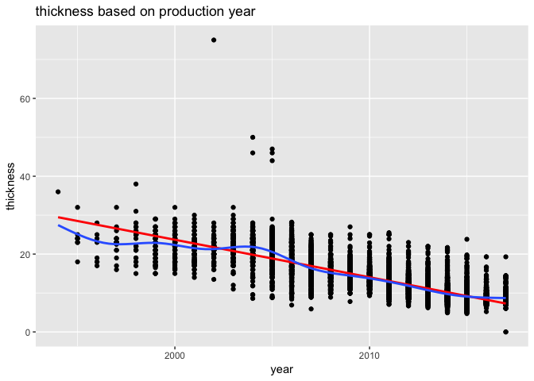

```r
# device_thickness = mobile %>% group_by(year) %>% summarise(average= mean(dim_thickness, na.rm = TRUE))

p_thickness = ggplot(data = mobile, mapping = aes(y = dim_thickness, x = year)) + geom_point(stat = "identity") + ggtitle('thickness based on production year') + geom_smooth(method = "lm", se = FALSE, colour="red") + geom_smooth(se = FALSE) + ylab("thickness")
p_thickness
```

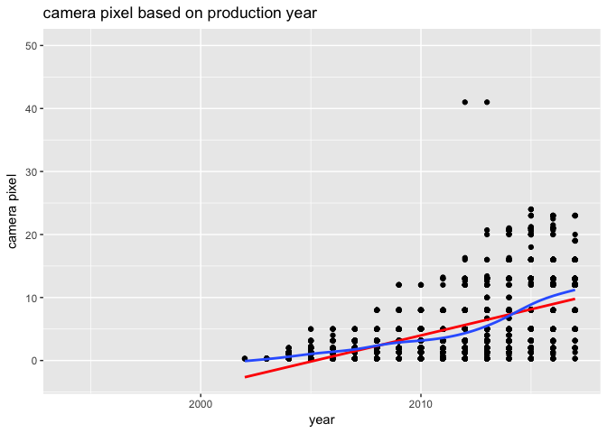

```r
# device_cam_px = mobile %>% group_by(year) %>% summarise(average= mean(cam_px, na.rm = TRUE))

p_cam_px = ggplot(data = mobile, mapping = aes(y = cam_px, x = year)) + geom_point(stat = "identity") + ggtitle('camera pixel based on production year') + geom_smooth(method = "lm", se = FALSE, colour="red") + geom_smooth(se = FALSE) + ylab("camera pixel")
p_cam_px
```

۳. نمودار ستونی متوسط قیمت گوشی بر حسب تعداد سیم کارت و دسترسی به LTE را رسم نمایید.

در این نمودار ابتدا بر اساس تعداد سیم کارت و LTE گروه بندی می کنیم و در نهایت میانگین قیمت را برای هر گروه بدست می آوریم و نمودار مربوطه را رسم می کنیم.

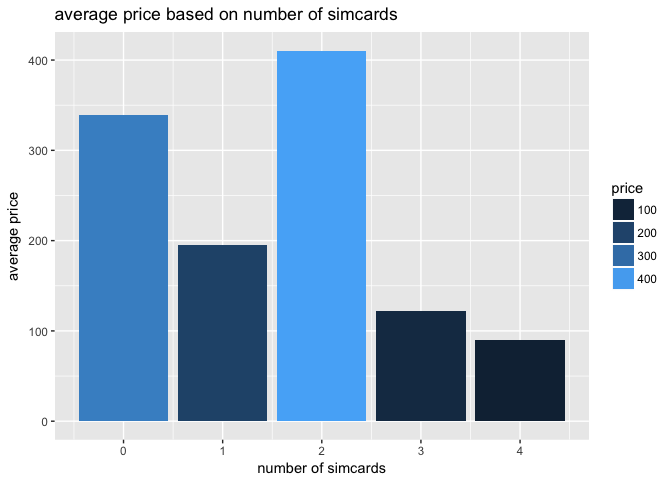

```r
sim_num_price = mobile %>% group_by(sim_no) %>% summarise(average= mean(price, na.rm = TRUE))

p = ggplot(data = sim_num_price, aes(y = average, x = sim_no, fill = average)) + geom_bar(stat="identity") + ggtitle('average price based on number of simcards') + xlab('number of simcards') + ylab('average price') + guides(fill=guide_legend(title="price"))
p
```

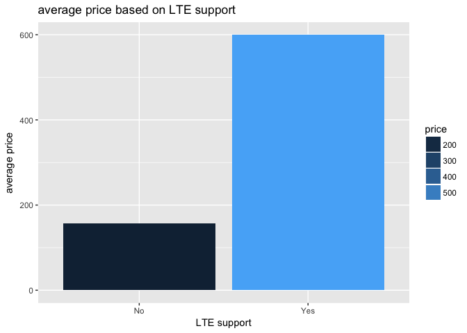

```r
lte_price = mobile %>% group_by(LTE) %>% summarise(average= mean(price, na.rm = TRUE))

p_lte = ggplot(data = lte_price, aes(y = average, x = LTE, fill = average)) + geom_bar(stat="identity") + ggtitle('average price based on LTE support') + xlab('LTE support') + ylab('average price') + guides(fill=guide_legend(title="price"))
p_lte
```

برای نمایش نمودار هر دو متغیر LTE و تعداد سیم کارت، یک متغیری که حاصل ترکیب این دو مقادیر است را با تابع interaction بدست می آوریم و سپس بر اساس این مقدار گروه بندی کرده و میانگین قیمت هر گروه از گوشی ها را بدست می آوریم.

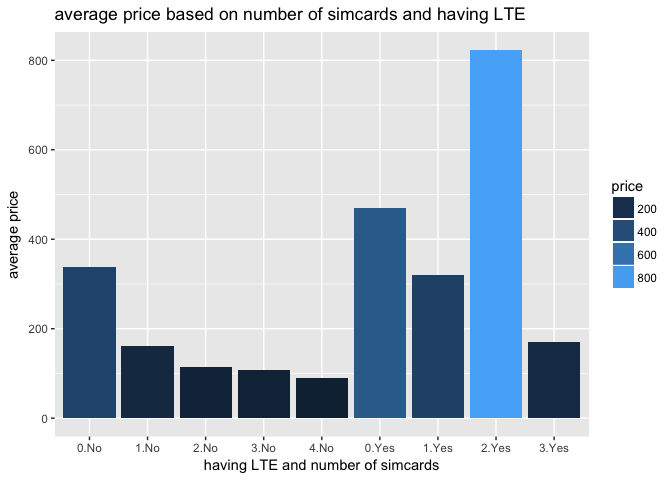

```r
mobile = mobile %>% mutate(sim_lte = interaction(sim_no, LTE))
View(mobile)

mobile_lte_price = mobile %>% group_by(sim_lte) %>% summarise(average= mean(price, na.rm = TRUE))

p_lte_price = ggplot(data = mobile_lte_price, aes(y = average, x = sim_lte, fill = average)) + geom_bar(stat="identity") + ggtitle('average price based on number of simcards and having LTE') + xlab('having LTE and number of simcards') + ylab('average price') + guides(fill=guide_legend(title="price"))
p_lte_price
```

۴. نمودار جعبه ایی ضحامت گوشی هایی که در سال ۲۰۱۷ معرفی شده اند را برحسب اینکه کمیت جک هدفون رسم نمایید

برای بدست آوردن دستگاه هایی که در سال ۲۰۱۷ معرفی شده اند، می بایست وجود رشته ی “2017” را در رشته ی announced بدست آوریم، که برای این منظور از تابع str_detect از کتاب خانه ی stringr استفاده می کنیم. در نهایت نیز برای رسم نمودار جعبه ای از دستور geom_boxplot بهره می بریم.

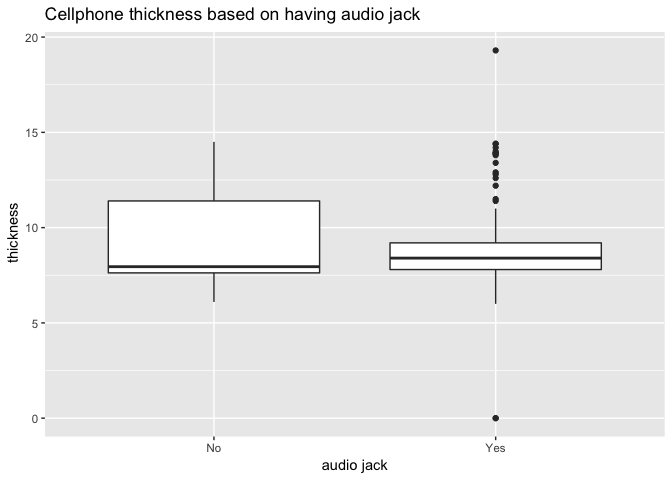

```r
library(stringr)
last_year_announce = mobile[which(str_detect(mobile$announced, "2017") == TRUE), ]

p = ggplot(data = subset(last_year_announce, !is.na(audio_jack)), aes(y = dim_thickness, x = audio_jack)) + geom_boxplot() + xlab("audio jack") + ylab(" thickness") + ggtitle("Cellphone thickness based on having audio jack")
p
```

۵. مفهوم ppi را در گوشی های موبایل محاسبه و هیستوگرام آن را رسم نمایید. همچنین نمودار سالانه متوسط این کمیت را بکشید. کدام گوشی بیشترین ppi را دارد؟

برای بدست آوردن مقدار ppi از نسبت قطر صفحه بر اساس تعداد پیکسل به قطر صفحه بر اساس inch استفاده می کنیم. در نهایت نیز برای میانگین ppi بر اساس سال گروه بندی کرده و میانگین را برای هر گروه بدست می آوریم.

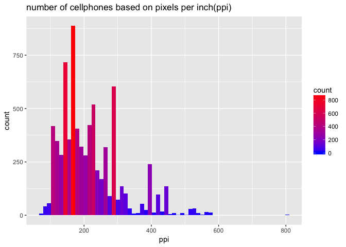

```r
mobile$ppi <- with(mobile, round(sqrt((mobile$px_row^2)+(mobile$px_col^2))/(mobile$display_size)))
mobile_nafree <- subset(mobile, !is.na(ppi))
p = ggplot(data = mobile_nafree, mapping = aes(x = ppi, fill=..count..)) + geom_histogram(binwidth = 12) + scale_fill_gradient(low="blue", high="red") + ggtitle("number of cellphones based on pixels per inch(ppi)")
p
```

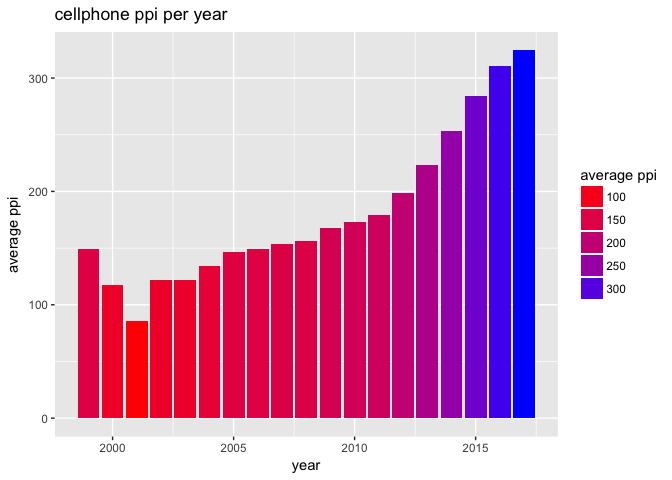

```r
device_ppi = mobile_nafree %>% group_by(year) %>% summarise(average= mean(ppi, na.rm = TRUE))
p_ppi = ggplot(data = device_ppi, mapping = aes(y = average, x = year, fill = average)) + geom_bar(stat="identity") + scale_fill_gradient(low="red", high="blue") + ggtitle("cellphone ppi per year") + ylab("average ppi") + guides(fill=guide_legend(title="average ppi"))
p_ppi
```

```r
cat("highest ppi cellphone name: ", (mobile_nafree$device[which.max(mobile_nafree$ppi)]), 'ppi:', (mobile_nafree$ppi[which.max(mobile_nafree$ppi)]))
```

```
highest ppi cellphone name:  Xperia XZ Premium ppi: 807
```

۶. در گذشته به بعضی از مدل های گوشی نوکیا **گوشکوب** گفته می شد. سعی کنید برای این مفهوم کمیتی مناسب تعریف کنید . ده گوشکوب برتر را پیدا کرده و نمودار گوشکوبیت آن را رسم نمایید.

[figure not shown]

```r
mobile$desit <- with(mobile, (mobile$weight)/(mobile$dim_length*mobile$dim_breadth*mobile$dim_thickness))
mobile_nafree <- subset(mobile, !is.na(desit))

mobile_goosh = mobile_nafree %>% filter(dim_thickness > 20) %>% filter(display_size < 3) %>% filter(desit > 0.0008)
mobile_goosh = mobile_goosh %>% mutate(gooshkubi = (dim_thickness*desit)/display_size)
gooshkub_top10 = head(mobile_goosh[order(mobile_goosh$gooshkubi, decreasing = TRUE), ], 10)

p = ggplot(data = gooshkub_top10, aes(y = gooshkubi, x = device, fill = gooshkubi)) + geom_bar(stat="identity") + scale_fill_gradient(low="steelblue", high="midnightblue") + ggtitle("top 20 gooshkubs") + xlab("devices") + ylab("gooshkubi") + theme(axis.text.x = element_text(angle = 45, hjust = 1))
p
```

۷. آیا تلفن همراهی وجود دارد که در آب غرق نشود؟ اگر جواب بله هست تمام گوشی های که این خاصیت را دارند بیابید. با کشیدن یک نمودار به این سوال پاسخ دهید.

برای تشخیص غرق شدن در آب چگالی هر گوشی را بدست می آوریم که از نسبت جرم به حجم بدست می آید. هم چنین برای بدست آوردن حجم گوشی، حاصلضرب طول و عرض و ارتفاع را بدست می آوریم.  
حال گوشی هایی که دارای چگالی کمتر از چگالی آب بر حسب گرم بر میلی متر مکعب هستند، بر روی آب شناور می مانند. (چگالی آب = ۰.۰۰۱ گرم بر میلی متر معکب)  
مشاهده می کنیم که حدود ۱۰۱۴ دستگاه بر روی ب شناور می مانند.

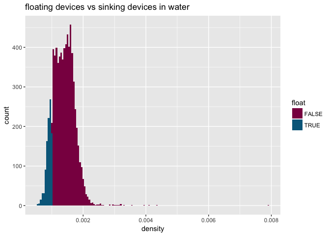

```r
mobile$desit <- with(mobile, (mobile$weight)/(mobile$dim_length*mobile$dim_breadth*mobile$dim_thickness))
mobile_nafree <- subset(mobile, !is.na(desit))

mobile_nafree$float <- ifelse(mobile_nafree$desit < 0.001, TRUE, FALSE)
View(mobile_nafree[which(mobile_nafree$float == TRUE), ])

gs.pal <- colorRampPalette(c("deeppink4","deepskyblue4"))

p_float = ggplot(data = mobile_nafree, mapping = aes(x = desit, fill = float)) + geom_histogram(position="identity", binwidth = 0.00005) + xlab("density") + ylab("count") + ggtitle("floating devices vs sinking devices in water") + scale_fill_manual(values=gs.pal(2))
p_float
```

۸. نمودار پراکنش حجم ذخیره سازی باطری و وزن را رسم نمایید. میزان همبستگی بین این دو کمیت را محاسبه کنید.

برای نمایش نمودار از scatter plot استفاده می کنیم.

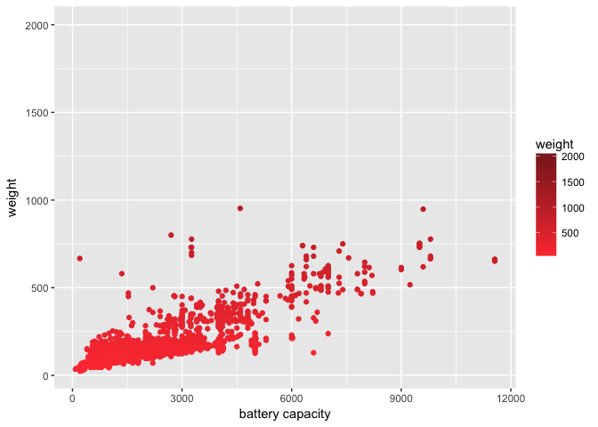

```r
battery_weigth = ggplot(data = mobile, mapping = aes(x = battery_mah, y = weight, color = weight)) + geom_point(stat = "identity") + xlab("battery capacity") + ylab("weight") + scale_color_gradient(low="brown1", high="brown4")
battery_weigth
```

هم چنین برای دست آوردن میزان همبستگی این دو متغیر از تابع cor استفاده می کنیم.

```r
bat_nafree = subset(mobile, !is.na(battery_mah))
mobile_nafree = subset(bat_nafree, !is.na(weight))

cat("correlation between battery capacity and weight: ", cor(mobile_nafree$battery_mah, mobile_nafree$weight))
```

```
correlation between battery capacity and weight:  0.8086273
```

۹. قیمت پرچمداران یک برند خاص مثلا سامسونگ را بیابید و نمودار قیمت زمان و نام مدل را رسم نمایید.

برای بدست آوردن پرچم داران برند HTC ابتدا بر اساس سال گروه بندی کرده و سپس بیشترین قیمت هر سال را بدست می آوریم.

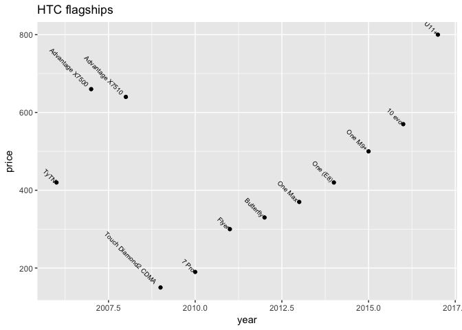

```r
htc_dev = mobile %>% filter(company=="HTC")
htc_dev = subset(htc_dev, !is.na(price))

htc_dev = htc_dev %>% group_by(year) %>% filter(price == max(price)) %>% distinct(year, .keep_all = TRUE)
View(htc_dev)

flagship = ggplot(data = htc_dev, mapping = aes(x = year, y = price)) + geom_point(stat="identity") + ggtitle("HTC flagships") + geom_text(mapping = aes(label = device), angle = -45, hjust = 1.1, size = 2.5)
flagship
```

۱۰. سه نمودار جالب رسم کنید و توضیح دهید چرا از نظر شما جالب است؟

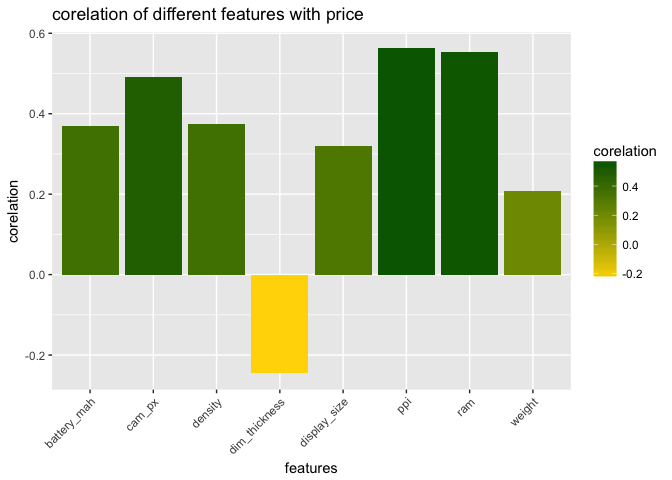

```r
# corelation of fields to price
mobile <- mobile[which(mobile$company != "QMobile"),]
mobile <- mobile[which(mobile$price < 3000),]
mobile <- subset(mobile, !is.na(price))
mobile <- subset(mobile, !is.na(battery_mah))
mobile <- subset(mobile, !is.na(weight))
mobile <- subset(mobile, !is.na(dim_thickness))
mobile <- subset(mobile, !is.na(display_size))
mobile <- subset(mobile, !is.na(cam_px))
mobile <- subset(mobile, !is.na(ram))

mobile$ppi <- with(mobile, round(sqrt((mobile$px_row^2)+(mobile$px_col^2))/(mobile$display_size)))
mobile <- subset(mobile, !is.na(ppi))

mobile$desit <- with(mobile, (mobile$weight)/(mobile$dim_length*mobile$dim_breadth*mobile$dim_thickness))
mobile <- subset(mobile, !is.na(desit))

features <- c('battery_mah','weight','dim_thickness', 'display_size', 'cam_px', 'ram', 'ppi', 'density')
corelation <- c(cor(mobile$price, mobile$battery_mah), cor(mobile$price, mobile$weight), cor(mobile$price, mobile$dim_thickness), cor(mobile$price, mobile$display_size), cor(mobile$price, mobile$cam_px), cor(mobile$price, mobile$ram), cor(mobile$price, mobile$ppi), cor(mobile$price, mobile$desit))
my <- data.frame(features, corelation)

p1 = ggplot(data = my, mapping = aes(x = features, y = corelation, fill = corelation)) + ggtitle("corelation of different features with price") + geom_bar(stat="identity") + scale_fill_gradient(low="gold", high="darkgreen") + theme(axis.text.x = element_text(angle = 45, hjust = 1))
p1
```

**نمودار تغییرات قیمت در طول سال**  
در این نمودار تغییرات میانگین قیمت گوشی های مختلف در طول سال ها را مشاهده می کنیم.  
علت جالب بودن این نمودار نیز این است که با اضافه تر شدن ویژگی های متخلف شرکت های روند افزایش قیمت گوشی ها را در پیش گرفته اند و از دو سال پیش نیز این افزایش قیمت های بسیار بیشتر شده است.

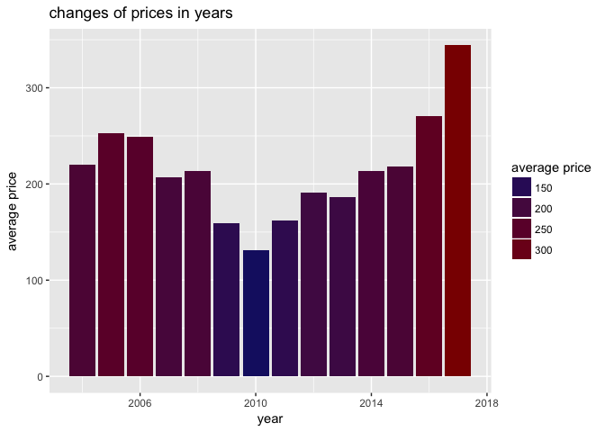

```r
# average price in years
mobile_price <- mobile %>% group_by(year) %>% summarise(price_average = mean(price , na.rm = TRUE))
p2 = ggplot(data = mobile_price, mapping = aes(x = year, y = price_average, fill = price_average)) + ggtitle("changes of prices in years") + geom_bar(stat="identity") + scale_fill_gradient(low="midnightblue", high="darkred") + ylab("average price") + guides(fill=guide_legend(title="average price"))
p2
```

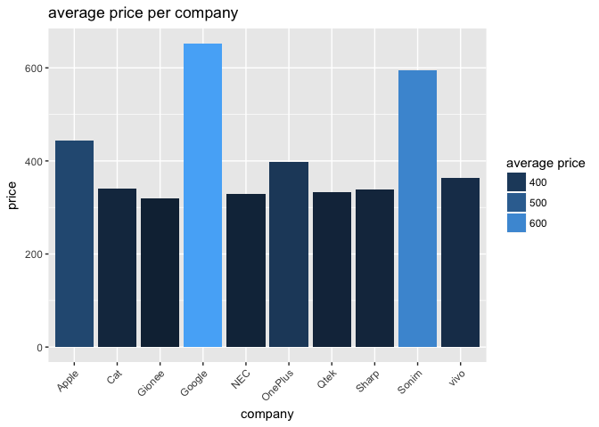

```r
# top 10 average price for each phone based on company
mobile_comp <- mobile %>% group_by(company) %>% summarise(ben = mean(price))
mobile_comp <- head(mobile_comp[order(mobile_comp$ben, decreasing = TRUE), ], 10)
p3 = ggplot(data = mobile_comp, mapping = aes(x = company, y = ben, fill = ben)) + ggtitle("average price per company") + geom_bar(stat="identity") + ylab("price") + guides(fill=guide_legend(title="average price")) + theme(axis.text.x = element_text(angle = 45, hjust = 1))
p3
```